# 16.3 Object Oriented Programming Details

From Prof. Chambers’ lecture, you have already been introduced to the OOP facilities in R. Here I will summarize them together and delve into the details.

# 16.3.1. OOP in R

*There are several OOP systems in R.*

- The venerable `S3` system, that you encounter evertime you use R. Informal, yet widely used with generic functions that define what happens when a function is called on the object
- The `S4` class , which is a more formal version, but you explictly define classes with slots. One can can define methods for your object and use generic functions to define which method gets called depending on the classes of arguments. Note that you can dispatch based on the class of any number of arguments, i.e. you have *multiple dispatch*.
- Reference classes (sometimes also called `R5` or `RC`) based on `S4` that provide OOP like Java to an extent.
- `R6` which is a newer facility provided by the package also named `R6` which are closer in spirit to the message passing systems that languages like Java use.

The key point to understand, as was emphasised by John Chambers, is that in the standard OOP, *methods and fields belong to classes*. That is in a language like Java, `foo.bar()` is a method named `bar` defined in class `foo`. Depending on the design of the class, that `bar` method may have access to some fields or even fields of its superclasses. But the key fact is that these are all aspects of the class.

On the other hand, in a functional language like R, all you have function calls. Therefore, your functions have to operate on objects if you want to implement OOP.

Which means that when a function `f(x, ...)` is called, there needs to be a way for the functional language to figure out what class `x` is and called the appropriate method corresponding to `f` on that class with arguments `...`. If the method modifies some feature of the object, generally a *copy* of the modified object is returned.

But since there could conceivably be many classes with method `f`, there needs to be a table that suggests what to do. Such a table, for example, could be used to make decisions such as:

- if `x` of class `foo`, call `foo.f(...)`
- if `x` is of class `bar`, call `bar.f(...)` etc. etc.

In summary, in a functional language, the construct `foo.f(...)` effectively has to be converted into `f(foo, ...)` via a *generic* function `f` that looks up a table to decide what to do.

# 16.3.2. The `S3` paradigm

This paradigm is an informal system that is still widely used. Basically, all it involves is assigning any R object a *class* attribute and voila it becomes an S3 class. Of course, to do anything useful using the class, you will have to write methods that actually behave the way you want the class the behave.

For example, `glmnet` is a popular package for regularized fitting of lasso or elastic-net models on large data sets.

```r
library(glmnet)
set.seed(1)
x <- matrix(data = rnorm(100 * 20), nrow = 100, ncol = 20)
y <- rnorm(100)
fit <- glmnet(x = x, y = y)
class(fit)
```

```
## [1] "elnet"  "glmnet"
```

In the above, the constructor function, i.e., the one that creates objects of a class, is effectively `glmnet`.

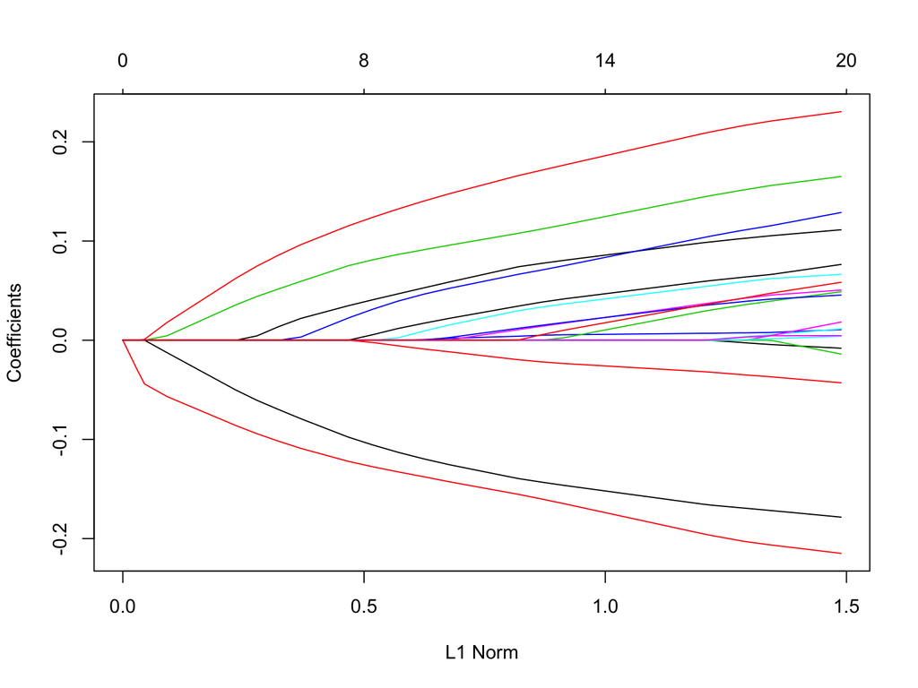

```r
plot(fit)
```

Now, how did `plot` know to generate a plot such as the one above?

We can examine this by looking at the source for the `plot` function

```r
plot
```

```
## function (x, y, ...)
## UseMethod("plot")
## <bytecode: 0x7ff6a63ed698>
## <environment: namespace:graphics>
```

The `UseMethod` call tells us that this is a generic function. It basically states: *use the appropriate method for the arguments passed to plot*.

So can we examine what possible methods are available for `plot`? Yes, using the `methods()` function.

```r
methods(plot)
```

```
##  [1] plot.acf*            plot.correspondence* plot.cv.glmnet*
##  [4] plot.cv.relaxed*     plot.data.frame*     plot.decomposed.ts*
##  [7] plot.default         plot.dendrogram*     plot.density*
## [10] plot.ecdf            plot.factor*         plot.formula*
## [13] plot.function        plot.glmnet*         plot.hclust*
## [16] plot.histogram*      plot.HoltWinters*    plot.isoreg*
## [19] plot.lda*            plot.lm*             plot.mca*
## [22] plot.medpolish*      plot.mlm*            plot.mrelnet*
## [25] plot.multnet*        plot.ppr*            plot.prcomp*
## [28] plot.princomp*       plot.profile*        plot.profile.nls*
## [31] plot.R6*             plot.raster*         plot.relaxed*
## [34] plot.ridgelm*        plot.shingle*        plot.spec*
## [37] plot.stepfun         plot.stl*            plot.table*
## [40] plot.trellis*        plot.ts              plot.tskernel*
## [43] plot.TukeyHSD*
## see '?methods' for accessing help and source code
```

Note that one of them is `plot.glmnet`. Ok, so what is the connection between `plot.glmnet` and `fit`? Note above that `fit` is of class `glmnet` (and also `elnet`, but there is not `plot.elnet`).

So, when we called `plot(fit)`, that got dispatched to `plot.glmnet(fit)` which knew what plot to produce.

To be sure, we can explicitly call that function to see if we get the same result.

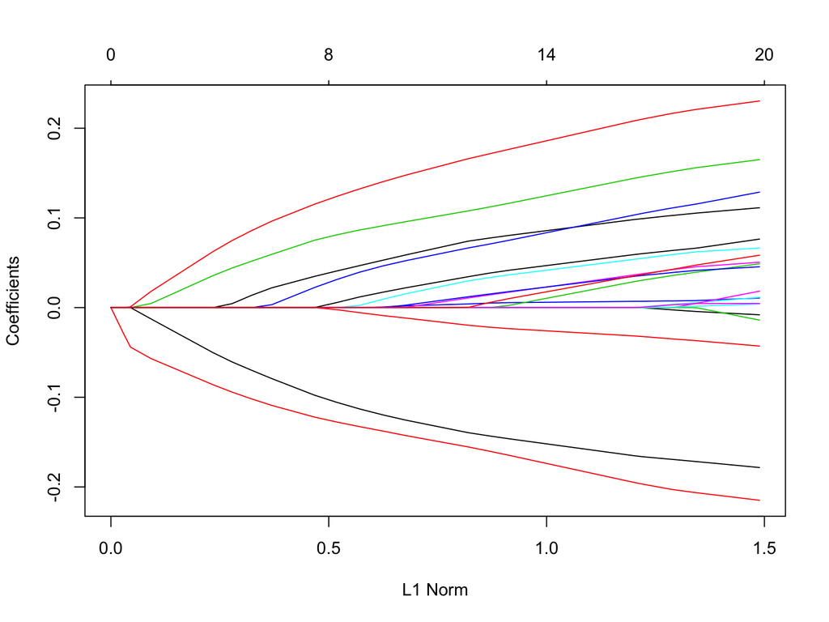

```r
glmnet:::plot.glmnet(fit)
```

**NOTE**: We use the three colon notation here because `plot.glmnet` is not an exported function from the `glmnet` package, and is internal to `glmnet`.

You can list the various generic functions for the class names.

For class `glmnet`.

```r
methods(class = "glmnet")
```

```
## [1] coef     deviance family   plot     predict  print
## see '?methods' for accessing help and source code
```

For class `elnet`.

```r
methods(class = "elnet")
```

```
## [1] predict
## see '?methods' for accessing help and source code
```

### 16.3.3. A bit more about generics

What about `+`? Is it generic?

```r
`+`
```

```
## function (e1, e2)  .Primitive("+")
```

So it appears not since there is no `UseMethod()` call, but it actually is. Why? Because, by listing the various methods for `+` we see that it actually behaves differently for different objects.

```r
methods(`+`)
```

```
## [1] +,dgTMatrix,dgTMatrix-method +,Matrix,missing-method
## [3] +.Date                       +.fs_path*
## [5] +.glue*                      +.POSIXt
## see '?methods' for accessing help and source code
```

This tells us that R knows what to do with `+` for dates and times!

Therefore, `UseMethod()` alone is not a good test and so the package `pryr` is a good help.

```r
library(pryr)
```

```r
ftype(plot)
```

```
## [1] "s3"      "generic"
```

```r
ftype(`+`)
```

```
## [1] "primitive" "generic"
```

### 16.3.4. Defining your own methods

When you have an S3 class, generics like `print` and `plot` are already available. So you don’t need to do anything special if you want to invoke a `print` or a `plot` method for your object.

For example, consider a data frame that can be plotted:

```r
d <- data.frame(a = 1:5, b = (1:5)^2)
class(d)
```

```
## [1] "data.frame"
```

If we invoke plot on it, it works fine.

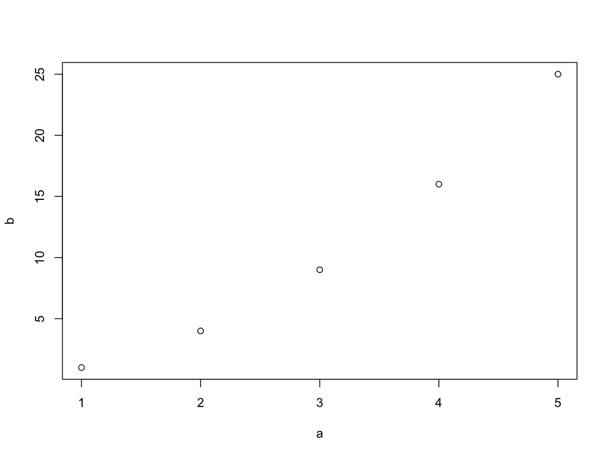

```r
plot(d)
```

As we discussed in lecture 9.1, what happened behind the scenes is that `graphics:::plot.data.frame` was called as can be seen from:

```r
methods(plot)
```

```
##  [1] plot.acf*            plot.correspondence* plot.cv.glmnet*
##  [4] plot.cv.relaxed*     plot.data.frame*     plot.decomposed.ts*
##  [7] plot.default         plot.dendrogram*     plot.density*
## [10] plot.ecdf            plot.factor*         plot.formula*
## [13] plot.function        plot.glmnet*         plot.hclust*
## [16] plot.histogram*      plot.HoltWinters*    plot.isoreg*
## [19] plot.lda*            plot.lm*             plot.mca*
## [22] plot.medpolish*      plot.mlm*            plot.mrelnet*
## [25] plot.multnet*        plot.ppr*            plot.prcomp*
## [28] plot.princomp*       plot.profile*        plot.profile.nls*
## [31] plot.R6*             plot.raster*         plot.relaxed*
## [34] plot.ridgelm*        plot.shingle*        plot.spec*
## [37] plot.stepfun         plot.stl*            plot.table*
## [40] plot.trellis*        plot.ts              plot.tskernel*
## [43] plot.TukeyHSD*
## see '?methods' for accessing help and source code
```

and

```r
getAnywhere("plot.data.frame")
```

```
## A single object matching 'plot.data.frame' was found
## It was found in the following places
##   registered S3 method for plot from namespace graphics
##   namespace:graphics
## with value
##
## function (x, ...)
## {
##     plot2 <- function(x, xlab = names(x)[1L], ylab = names(x)[2L],
##         ...) plot(x[[1L]], x[[2L]], xlab = xlab, ylab = ylab,
##         ...)
##     if (!is.data.frame(x))
##         stop("'plot.data.frame' applied to non data frame")
##     if (ncol(x) == 1) {
##         x1 <- x[[1L]]
##         if (class(x1)[1L] %in% c("integer", "numeric"))
##             stripchart(x1, ...)
##         else plot(x1, ...)
##     }
##     else if (ncol(x) == 2) {
##         plot2(x, ...)
##     }
##     else {
##         pairs(data.matrix(x), ...)
##     }
## }
## <bytecode: 0x7ff6afcf2918>
## <environment: namespace:graphics>
```

Now suppose we want to use `ggplot2` instead of base plot for the scatterplot.

One way we could do this is to change the class.

```r
class(d) <- c("ggplot_able", class(d))
class(d)
```

```
## [1] "ggplot_able" "data.frame"
```

Now we have to define our own method for plotting, borrowing from `graphics:::plot.data.frame`.

```r
plot.ggplot_able <- function(x, ...) {
    stopifnot(require("ggplot2"))
    plot2 <- function(x, xlab = names(x)[1L], ylab = names(x)[2L],
        ...) qplot(x[[1L]], x[[2L]], xlab = xlab, ylab = ylab,
        ...)
    if (!is.data.frame(x))
        stop("'plot.ggplot_able' applied to non data frame")
    if (ncol(x) == 1) {
        qplot(x[[1L]], ...)
    } else if (ncol(x) == 2) {
        plot2(x, ...)
    } else {
        stop("plot.ggplot_able: Don't know what to do")
    }
}
```

And try it.

```
## RStudio Community is a great place to get help:
## https://community.rstudio.com/c/tidyverse.
```

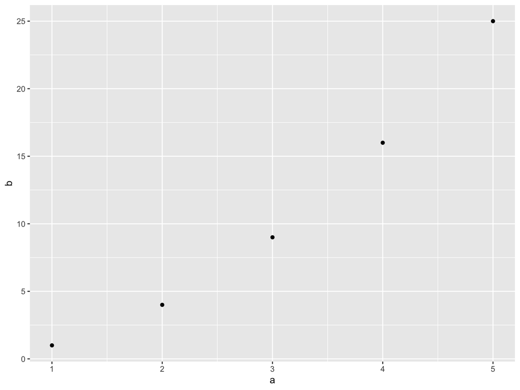

```r
plot(d)
```

It works.

But what if you have a new method that *you* want to write? For example, a function for returning a particular row in a data frame.

Use `UseMethod`.

```r
nthRow.data.frame <- function(x, n) {
    if (0L < n && n <= nrow(x))
        x[n, ]
    else
        stop("nthRow.data.frame: Bad value for n")
}

nthRow <- function(x, n) UseMethod("nthRow")
```

And we can check.

```r
nthRow(d, 2)
```

```
##   a b
## 2 2 4
```

# 16.3.5. Ramifications

1. Because of this association of the period with methods for S3 objects, it is best to avoid periods in names of functions, even though it is legitimate; it makes those functions look like methods for S3 objects. So many people have started using camel-case or underscores to avoid such confusion.
2. There can be issues if two different packages define the same S3 classes and methods for them. A recent example was the case of `mgcv` and `gam` both of which defined S3 classes called `gam` and methods.
3. The S3 system provides all sorts of opportunities for you to shoot yourself in the foot. Consider for example the following.

```r
class(d) <- "foobar"
plot(d)
```

```
## Error in xy.coords(x, y, xlabel, ylabel, log): 'x' is a list, but does not have components 'x' and 'y'
```

What happened? We changed the class attribute of `d` to be something other than a `data.frame` and so plot went ahead and called a default method `plot.default`, the catch-all. And all hell broke loose.

Since class is merely an attribute in the `S3` system. nothing stops you from changing it. So there are no guarantees with this type of class system.

A more formal system called `S4` overcomes these issues.